# Explore initial sample data

Ben Anderson

Last run at: 2019-10-16 09:19:25

# 1 Introduction

Exploration of various data sets on a set of residential `virtual power plant` installations. These have PV, batteries and hot water controllers.

# 2 To do

# 3 Test Data

This will fail if you are not connected to the University of Otago HCS service where the data is archived.

## 3.1 RgAv_Sample_Data.csv.gz

Loaded: /Volumes/hum-csafe/Research Projects/GREEN Grid/externalData/solarCity/2018-07-06-sampleData/RgAv_Sample_Data.csv.gz

This data appears to be regional averages. We don’t know how many dwellings are covered in each region.

The following shows the original variable names and descriptives.

```
## Skim summary statistics
##  n obs: 2883462
##  n variables: 17
##
## ── Variable type:character ─────────────────────────────────────────────────────────────────────────────────────────────
##         variable missing complete       n min max empty n_unique
##  record time utc       0  2883462 2883462  19  19     0  2457316
##           region       0  2883462 2883462   0  19 20152       14
##
## ── Variable type:numeric ───────────────────────────────────────────────────────────────────────────────────────────────
##                     variable missing complete       n      mean     sd p0
##               battery charge       0  2883462 2883462   0.00053  0.012  0
##             electricity used   70439  2813023 2883462   0.22     1.25   0
##         grid electricty used   70439  2813023 2883462   0.18     1.17   0
##                      power 1       0  2883462 2883462   0.16     0.9    0
##                     power 1n       0  2883462 2883462   0.039    0.25   0
##                      power 2       0  2883462 2883462   0.044    0.42   0
##                     power 2n       0  2883462 2883462 232.96    24.83   0
##                      power 3       0  2883462 2883462   0.0097   0.081  0
##                     power 3n       0  2883462 2883462   0.005    0.15   0
##                      power 4       0  2883462 2883462   0.079    0.25   0
##                     power 4n       0  2883462 2883462   0.0026   0.031  0
##   solar electricity exported  119899  2763563 2883462   0.04     0.25   0
##  solar electricity generated   49413  2834049 2883462   0.08     0.25   0
##       solar electricity used  119899  2763563 2883462   0.045    0.16   0
##                      voltage       0  2883462 2883462   4.27     0.04   0
##     p25    p50    p75    p100     hist
##    0      0      0       0.98 ▇▁▁▁▁▁▁▁
##    0.06   0.12   0.27 1613.72 ▇▁▁▁▁▁▁▁
##    0.02   0.08   0.21 1534.42 ▇▁▁▁▁▁▁▁
##    0.01   0.07   0.19  932.83 ▇▁▁▁▁▁▁▁
##    0      0      0.01  160.42 ▇▁▁▁▁▁▁▁
##    0      0      0     601.59 ▇▁▁▁▁▁▁▁
##  233.01 235.72 238.17  254.63 ▁▁▁▁▁▁▁▇
##    0      0      0      48.48 ▇▁▁▁▁▁▁▁
##    0      0      0     147.96 ▇▁▁▁▁▁▁▁
##    0      0      0.1   143.28 ▇▁▁▁▁▁▁▁
##    0      0      0       9.45 ▇▁▁▁▁▁▁▁
##    0      0      0.01  160.42 ▇▁▁▁▁▁▁▁
##    0      0      0.11  143.28 ▇▁▁▁▁▁▁▁
##    0      0      0.06   88.85 ▇▁▁▁▁▁▁▁
##    4.25   4.27   4.3     6.52 ▁▁▁▁▁▇▁▁
```

Table 3.1: First 10 rows for Auckland ordered by dateTime NZ

| record time utc | region | electricity used | solar electricity generated | grid electricty used | solar electricity used | solar electricity exported | power 1 | power 2 | power 3 | power 4 | power 1n | power 3n | power 4n | battery charge | voltage | power 2n | dateTime | dateTimeNZ |
| --- | --- | --- | --- | --- | --- | --- | --- | --- | --- | --- | --- | --- | --- | --- | --- | --- | --- | --- |
| 2017-07-03 10:23:19 | Auckland | 0.00 | 0 | 0.00 | 0 | 0 | 0.00 | 0 | 0 | 0 | 0 | 0 | 0 | 0 | 4.19 | 0.00 | 2017-07-03 10:23:19 | 2017-07-03 22:23:19 |
| 2017-07-03 10:23:33 | Auckland | 0.00 | 0 | 0.00 | 0 | 0 | 0.00 | 0 | 0 | 0 | 0 | 0 | 0 | 0 | 4.27 | 0.00 | 2017-07-03 10:23:33 | 2017-07-03 22:23:33 |
| 2017-07-03 10:55:23 | Auckland | 0.00 | 0 | 0.00 | 0 | 0 | 0.00 | 0 | 0 | 0 | 0 | 0 | 0 | 0 | 4.21 | 0.00 | 2017-07-03 10:55:23 | 2017-07-03 22:55:23 |
| 2017-07-03 10:55:37 | Auckland | 0.00 | 0 | 0.00 | 0 | 0 | 0.00 | 0 | 0 | 0 | 0 | 0 | 0 | 0 | 4.21 | 0.00 | 2017-07-03 10:55:37 | 2017-07-03 22:55:37 |
| 2017-07-03 11:57:32 | Auckland | 0.00 | 0 | 0.00 | 0 | 0 | 0.00 | 0 | 0 | 0 | 0 | 0 | 0 | 0 | 4.18 | 0.00 | 2017-07-03 11:57:32 | 2017-07-03 23:57:32 |
| 2017-07-03 11:57:40 | Auckland | 0.00 | 0 | 0.00 | 0 | 0 | 0.00 | 0 | 0 | 0 | 0 | 0 | 0 | 0 | 4.21 | 0.00 | 2017-07-03 11:57:40 | 2017-07-03 23:57:40 |
| 2017-07-03 13:26:41 | Auckland | 0.00 | 0 | 0.00 | 0 | 0 | 0.00 | 0 | 0 | 0 | 0 | 0 | 0 | 0 | 4.29 | 0.00 | 2017-07-03 13:26:41 | 2017-07-04 01:26:41 |
| 2017-07-03 13:27:06 | Auckland | 0.00 | 0 | 0.00 | 0 | 0 | 0.00 | 0 | 0 | 0 | 0 | 0 | 0 | 0 | 4.26 | 0.00 | 2017-07-03 13:27:06 | 2017-07-04 01:27:06 |
| 2017-08-02 03:07:47 | Auckland | 0.00 | 0 | 0.00 | 0 | 0 | 0.00 | 0 | 0 | 0 | 0 | 0 | 0 | 0 | 4.12 | 0.00 | 2017-08-02 03:07:47 | 2017-08-02 15:07:47 |
| 2017-08-02 03:09:35 | Auckland | 0.01 | 0 | 0.01 | 0 | 0 | 0.01 | 0 | 0 | 0 | 0 | 0 | 0 | 0 | 4.23 | 236.49 | 2017-08-02 03:09:35 | 2017-08-02 15:09:35 |

There is no obvous pattern to the time stamps although it appears that there are pairs of observations close together.

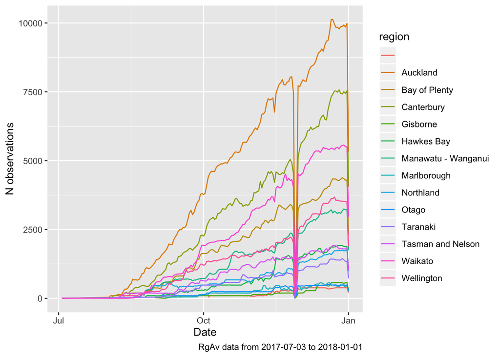

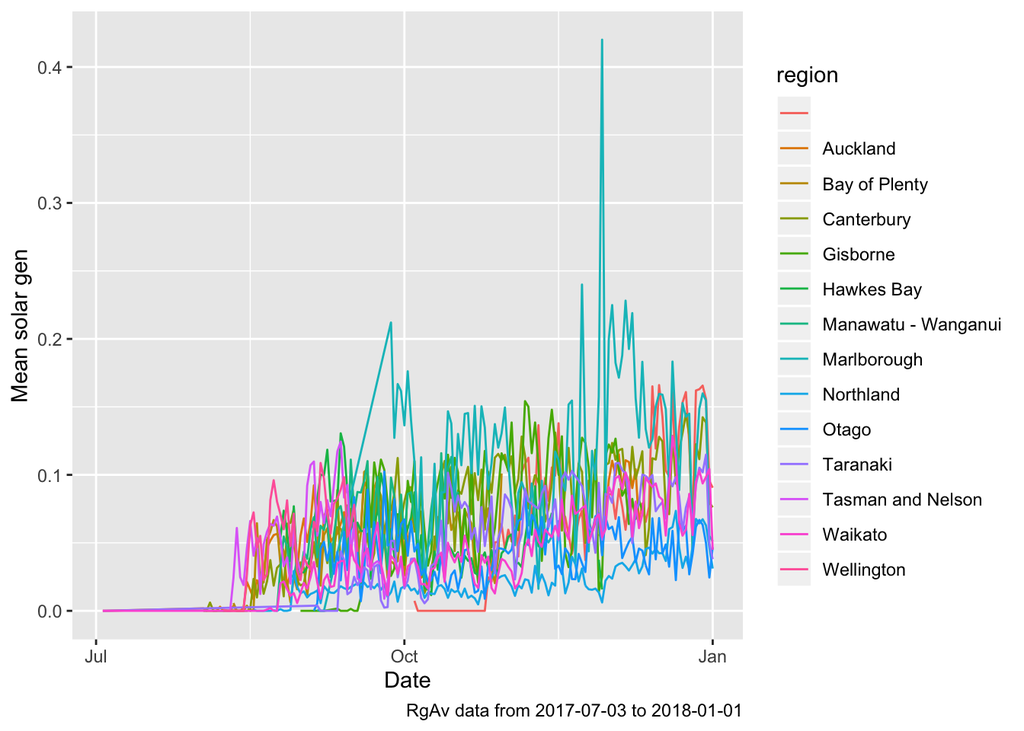

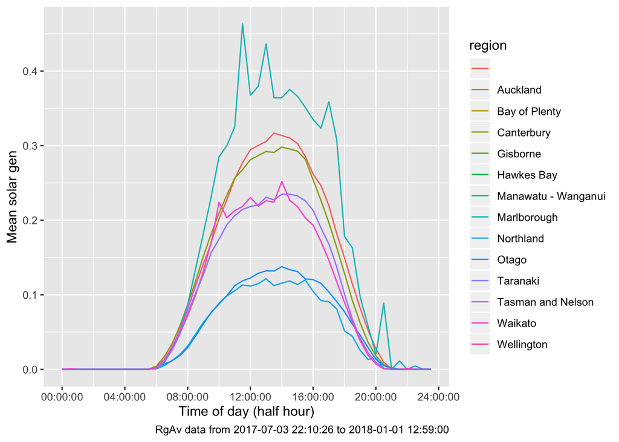

## 3.2 Sample Monitoring Data.csv.gz

Loaded: /Volumes//hum-csafe/Research Projects/GREEN Grid/externalData/solarCity/2018-07-06-sampleData/Sample Monitoring Data.csv.gz

This data appears to be a sample of the household level monitoring data. It appears to cover 917 differet `Sites`.

The following shows the original variable names and descriptives.

```
## Skim summary statistics
##  n obs: 85770
##  n variables: 17
##
## ── Variable type:character ─────────────────────────────────────────────────────────────────────────────────────────────
##           variable missing complete     n min max empty n_unique
##  RecordDateTimeUTC       0    85770 85770  15  16     0     1440
##
## ── Variable type:integer ───────────────────────────────────────────────────────────────────────────────────────────────
##  variable missing complete     n  mean  sd p0 p25 p50 p75 p100     hist
##      Site       0    85770 85770 458.2 264  1 230 457 687  917 ▇▇▇▇▇▇▇▇
##
## ── Variable type:numeric ───────────────────────────────────────────────────────────────────────────────────────────────
##                   variable missing complete     n      mean     sd   p0
##              BatteryCharge       0    85770 85770   4.25     0.041 3.31
##            ElectricityUsed    1813    83957 85770   0.39     4.36  0
##        GridElectricityUsed    1909    83861 85770   0.35     3.64  0
##                     Power1       0    85770 85770   0.32     3.59  0
##                    Power1N       0    85770 85770   0.017    0.34  0
##                     Power2       0    85770 85770   0.061    1.15  0
##                    Power2N       0    85770 85770   0.0055   0.045 0
##                     Power3       0    85770 85770   0.01     0.078 0
##                    Power3N       0    85770 85770   0.002    0.026 0
##                     Power4       0    85770 85770   0.05     1.25  0
##                    Power4N       0    85770 85770   0.00072  0.025 0
##   SolarElectricityExported    4160    81610 85770   0.018    0.35  0
##  SolarElectricityGenerated    2347    83423 85770   0.05     1.26  0
##       SolarElectricityUsed    4160    81610 85770   0.036    1.02  0
##                    Voltage       0    85770 85770 233.34    12.8   0
##      p25    p50     p75   p100     hist
##    4.22    4.25   4.27    4.39 ▁▁▁▁▁▁▇▃
##    0.073   0.22   0.52  961.19 ▇▁▁▁▁▁▁▁
##    0.048   0.18   0.49  800.48 ▇▁▁▁▁▁▁▁
##    0.037   0.16   0.46  800.48 ▇▁▁▁▁▁▁▁
##    0       0      0      87.2  ▇▁▁▁▁▁▁▁
##    0       0      0     269.99 ▇▁▁▁▁▁▁▁
##    0       0      0       0.85 ▇▁▁▁▁▁▁▁
##    0       0      0       2.98 ▇▁▁▁▁▁▁▁
##    0       0      0       0.87 ▇▁▁▁▁▁▁▁
##    0       0      0.037 247.91 ▇▁▁▁▁▁▁▁
##    0       0      0       6.29 ▇▁▁▁▁▁▁▁
##    0       0      0      87.2  ▇▁▁▁▁▁▁▁
##    0       0      0.039 247.91 ▇▁▁▁▁▁▁▁
##    0       0      0.029 216.39 ▇▁▁▁▁▁▁▁
##  230.99  234.25 237.27  254.22 ▁▁▁▁▁▁▁▇
```

Table 3.2: First 10 rows ordered by dateTime NZ

| RecordDateTimeUTC | Site | ElectricityUsed | SolarElectricityGenerated | GridElectricityUsed | SolarElectricityUsed | SolarElectricityExported | Power1 | Power2 | Power3 | Power4 | Power1N | Power2N | Power3N | Power4N | BatteryCharge | Voltage | dateTime | dateTimeNZ |
| --- | --- | --- | --- | --- | --- | --- | --- | --- | --- | --- | --- | --- | --- | --- | --- | --- | --- | --- |
| 27/05/2018 12:11 | 1 | 0.773 | 0.000 | 0.773 | 0.000 | 0 | 0.773 | 0 | 0 | 0.000 | 0 | 0 | 0 | 0.001 | 4.239 | 238.01 | 2018-05-27 12:11:00 | 2018-05-28 00:11:00 |
| 27/05/2018 12:26 | 1 | 0.487 | 0.000 | 0.487 | 0.000 | 0 | 0.487 | 0 | 0 | 0.000 | 0 | 0 | 0 | 0.001 | 4.277 | 241.40 | 2018-05-27 12:26:00 | 2018-05-28 00:26:00 |
| 27/05/2018 12:41 | 1 | 0.339 | 0.000 | 0.339 | 0.000 | 0 | 0.339 | 0 | 0 | 0.000 | 0 | 0 | 0 | 0.001 | 4.277 | 239.55 | 2018-05-27 12:41:00 | 2018-05-28 00:41:00 |
| 27/05/2018 12:56 | 1 | 0.704 | 0.000 | 0.703 | 0.000 | 0 | 0.703 | 0 | 0 | 0.000 | 0 | 0 | 0 | 0.001 | 4.271 | 240.48 | 2018-05-27 12:56:00 | 2018-05-28 00:56:00 |
| 27/05/2018 13:11 | 1 | 0.723 | 0.000 | 0.723 | 0.000 | 0 | 0.723 | 0 | 0 | 0.000 | 0 | 0 | 0 | 0.001 | 4.252 | 241.19 | 2018-05-27 13:11:00 | 2018-05-28 01:11:00 |
| 27/05/2018 13:26 | 1 | 0.693 | 0.000 | 0.693 | 0.000 | 0 | 0.693 | 0 | 0 | 0.000 | 0 | 0 | 0 | 0.001 | 4.265 | 239.25 | 2018-05-27 13:26:00 | 2018-05-28 01:26:00 |
| 27/05/2018 13:41 | 1 | 0.269 | 0.000 | 0.268 | 0.000 | 0 | 0.268 | 0 | 0 | 0.000 | 0 | 0 | 0 | 0.001 | 4.258 | 242.49 | 2018-05-27 13:41:00 | 2018-05-28 01:41:00 |
| 27/05/2018 13:56 | 1 | 0.549 | 0.000 | 0.548 | 0.000 | 0 | 0.548 | 0 | 0 | 0.000 | 0 | 0 | 0 | 0.001 | 4.277 | 240.58 | 2018-05-27 13:56:00 | 2018-05-28 01:56:00 |
| 27/05/2018 14:11 | 1 | 0.788 | 0.000 | 0.788 | 0.000 | 0 | 0.788 | 0 | 0 | 0.000 | 0 | 0 | 0 | 0.001 | 4.252 | 239.52 | 2018-05-27 14:11:00 | 2018-05-28 02:11:00 |
| 27/05/2018 14:26 | 1 | 0.676 | 0.001 | 0.675 | 0.001 | 0 | 0.675 | 0 | 0 | 0.001 | 0 | 0 | 0 | 0.001 | 4.239 | 238.44 | 2018-05-27 14:26:00 | 2018-05-28 02:26:00 |

These appear to be 15 minute observations.

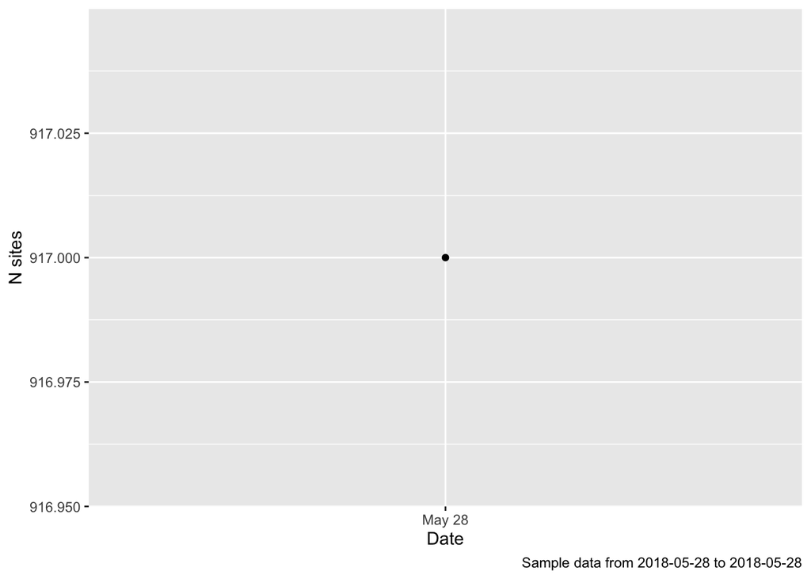

Figure 3.1 shows the mean solar electricity generated per half-hour by each site. There may be some outliers or data errors…

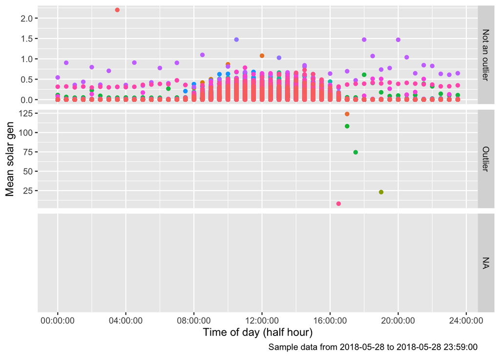

Figure 3.1: Mean solar generated (legend hidden for clarity)

Figure 3.2 shows the mean solar electricity exported by time of day.

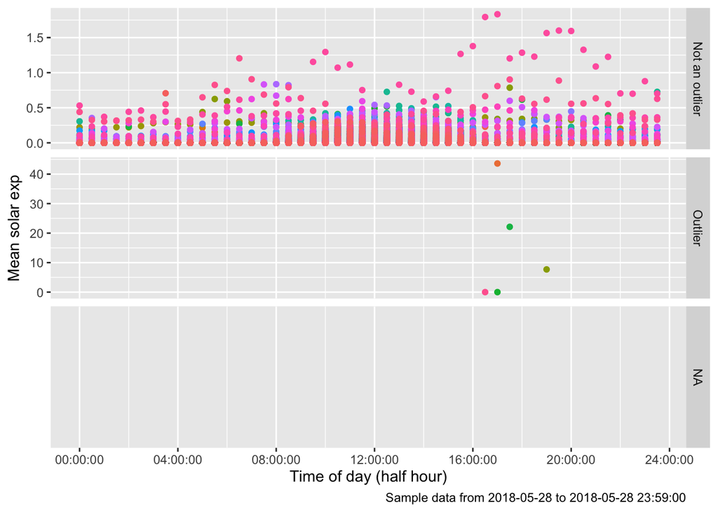

Figure 3.2: Mean exported per site (legend hidden for clarity)

# 4 About

R packages used:

Plus:

- bookdown (Xie 2016a)
- knitr (Xie 2016b)

Analysis completed in 92.442 seconds ( 1.54 minutes) using knitr in [RStudio](http://www.rstudio.com) with R version 3.5.2 (2018-12-20) running on x86_64-apple-darwin15.6.0. # References

Arino de la Rubia, Eduardo, Hao Zhu, Shannon Ellis, Elin Waring, and Michael Quinn. 2017. *Skimr: Skimr*. https://github.com/ropenscilabs/skimr.

Dowle, M, A Srinivasan, T Short, S Lianoglou with contributions from R Saporta, and E Antonyan. 2015. *Data.table: Extension of Data.frame*. https://CRAN.R-project.org/package=data.table.

Grolemund, Garrett, and Hadley Wickham. 2011. “Dates and Times Made Easy with lubridate.” *Journal of Statistical Software* 40 (3): 1–25. http://www.jstatsoft.org/v40/i03/.

Wickham, Hadley. 2009. *Ggplot2: Elegant Graphics for Data Analysis*. Springer-Verlag New York. http://ggplot2.org.

Xie, Yihui. 2016a. *Bookdown: Authoring Books and Technical Documents with R Markdown*. Boca Raton, Florida: Chapman; Hall/CRC. https://github.com/rstudio/bookdown.

———. 2016b. *Knitr: A General-Purpose Package for Dynamic Report Generation in R*. https://CRAN.R-project.org/package=knitr.

Zhu, Hao. 2018. *KableExtra: Construct Complex Table with ’Kable’ and Pipe Syntax*. https://CRAN.R-project.org/package=kableExtra.